# Exploring the ford go bike dataset

## Preliminary Wrangling

The dataset looks at the ford go bikes for the year 2017. It will be interesting to see what locations and possible routes are most used to help make decisions for future expansion or realocation of bikes.

```python
# import all packages and set plots to be embedded inline
import numpy as np
import pandas as pd
import matplotlib.pyplot as plt
import seaborn as sb

%matplotlib inline
```

```python
df = pd.read_csv('2017-fordgobike-tripdata.csv')
```

```python
print(df.shape)
print(df.dtypes)
print(df.head(5))
df.head()
```

```
(519700, 15)
duration_sec                 int64
start_time                  object
end_time                    object
start_station_id             int64
start_station_name          object
start_station_latitude     float64
start_station_longitude    float64
end_station_id               int64
end_station_name            object
end_station_latitude       float64
end_station_longitude      float64
bike_id                      int64
user_type                   object
member_birth_year          float64
member_gender               object
dtype: object
   duration_sec                start_time                  end_time  \
0         80110  2017-12-31 16:57:39.6540  2018-01-01 15:12:50.2450
1         78800  2017-12-31 15:56:34.8420  2018-01-01 13:49:55.6170
2         45768  2017-12-31 22:45:48.4110  2018-01-01 11:28:36.8830
3         62172  2017-12-31 17:31:10.6360  2018-01-01 10:47:23.5310
4         43603  2017-12-31 14:23:14.0010  2018-01-01 02:29:57.5710

   start_station_id                                 start_station_name  \
0                74                              Laguna St at Hayes St
1               284  Yerba Buena Center for the Arts (Howard St at ...
2               245                             Downtown Berkeley BART
3                60                               8th St at Ringold St
4               239                      Bancroft Way at Telegraph Ave

   start_station_latitude  start_station_longitude  end_station_id  \
0               37.776435              -122.426244              43
1               37.784872              -122.400876              96
2               37.870348              -122.267764             245
3               37.774520              -122.409449               5
4               37.868813              -122.258764             247

                                    end_station_name  end_station_latitude  \
0  San Francisco Public Library (Grove St at Hyde...             37.778768
1                              Dolores St at 15th St             37.766210
2                             Downtown Berkeley BART             37.870348
3       Powell St BART Station (Market St at 5th St)             37.783899
4                          Fulton St at Bancroft Way             37.867789

   end_station_longitude  bike_id   user_type  member_birth_year member_gender
0            -122.415929       96    Customer             1987.0          Male
1            -122.426614       88    Customer             1965.0        Female
2            -122.267764     1094    Customer                NaN           NaN
3            -122.408445     2831    Customer                NaN           NaN
4            -122.265896     3167  Subscriber             1997.0        Female
```

|  | duration_sec | start_time | end_time | start_station_id | start_station_name | start_station_latitude | start_station_longitude | end_station_id | end_station_name | end_station_latitude | end_station_longitude | bike_id | user_type | member_birth_year | member_gender |
| --- | --- | --- | --- | --- | --- | --- | --- | --- | --- | --- | --- | --- | --- | --- | --- |
| 0 | 80110 | 2017-12-31 16:57:39.6540 | 2018-01-01 15:12:50.2450 | 74 | Laguna St at Hayes St | 37.776435 | -122.426244 | 43 | San Francisco Public Library (Grove St at Hyde... | 37.778768 | -122.415929 | 96 | Customer | 1987.0 | Male |
| 1 | 78800 | 2017-12-31 15:56:34.8420 | 2018-01-01 13:49:55.6170 | 284 | Yerba Buena Center for the Arts (Howard St at ... | 37.784872 | -122.400876 | 96 | Dolores St at 15th St | 37.766210 | -122.426614 | 88 | Customer | 1965.0 | Female |
| 2 | 45768 | 2017-12-31 22:45:48.4110 | 2018-01-01 11:28:36.8830 | 245 | Downtown Berkeley BART | 37.870348 | -122.267764 | 245 | Downtown Berkeley BART | 37.870348 | -122.267764 | 1094 | Customer | NaN | NaN |
| 3 | 62172 | 2017-12-31 17:31:10.6360 | 2018-01-01 10:47:23.5310 | 60 | 8th St at Ringold St | 37.774520 | -122.409449 | 5 | Powell St BART Station (Market St at 5th St) | 37.783899 | -122.408445 | 2831 | Customer | NaN | NaN |
| 4 | 43603 | 2017-12-31 14:23:14.0010 | 2018-01-01 02:29:57.5710 | 239 | Bancroft Way at Telegraph Ave | 37.868813 | -122.258764 | 247 | Fulton St at Bancroft Way | 37.867789 | -122.265896 | 3167 | Subscriber | 1997.0 | Female |

```python
df_copy = df
```

```python
#Checking null vaules
d=df_copy.isnull()
d.head(10)
```

|  | duration_sec | start_time | end_time | start_station_id | start_station_name | start_station_latitude | start_station_longitude | end_station_id | end_station_name | end_station_latitude | end_station_longitude | bike_id | user_type | member_birth_year | member_gender |
| --- | --- | --- | --- | --- | --- | --- | --- | --- | --- | --- | --- | --- | --- | --- | --- |
| 0 | False | False | False | False | False | False | False | False | False | False | False | False | False | False | False |
| 1 | False | False | False | False | False | False | False | False | False | False | False | False | False | False | False |
| 2 | False | False | False | False | False | False | False | False | False | False | False | False | False | True | True |
| 3 | False | False | False | False | False | False | False | False | False | False | False | False | False | True | True |
| 4 | False | False | False | False | False | False | False | False | False | False | False | False | False | False | False |
| 5 | False | False | False | False | False | False | False | False | False | False | False | False | False | True | True |
| 6 | False | False | False | False | False | False | False | False | False | False | False | False | False | False | False |
| 7 | False | False | False | False | False | False | False | False | False | False | False | False | False | True | True |
| 8 | False | False | False | False | False | False | False | False | False | False | False | False | False | True | True |
| 9 | False | False | False | False | False | False | False | False | False | False | False | False | False | True | True |

```python
#dropping null values
df_copy =df_copy.dropna()
df_copy.info()
```

```
<class 'pandas.core.frame.DataFrame'>
Int64Index: 453159 entries, 0 to 519699
Data columns (total 15 columns):
duration_sec               453159 non-null int64
start_time                 453159 non-null object
end_time                   453159 non-null object
start_station_id           453159 non-null int64
start_station_name         453159 non-null object
start_station_latitude     453159 non-null float64
start_station_longitude    453159 non-null float64
end_station_id             453159 non-null int64
end_station_name           453159 non-null object
end_station_latitude       453159 non-null float64
end_station_longitude      453159 non-null float64
bike_id                    453159 non-null int64
user_type                  453159 non-null object
member_birth_year          453159 non-null float64
member_gender              453159 non-null object
dtypes: float64(5), int64(4), object(6)
memory usage: 55.3+ MB
```

```python
df.info()
```

```
<class 'pandas.core.frame.DataFrame'>
RangeIndex: 519700 entries, 0 to 519699
Data columns (total 15 columns):
duration_sec               519700 non-null int64
start_time                 519700 non-null object
end_time                   519700 non-null object
start_station_id           519700 non-null int64
start_station_name         519700 non-null object
start_station_latitude     519700 non-null float64
start_station_longitude    519700 non-null float64
end_station_id             519700 non-null int64
end_station_name           519700 non-null object
end_station_latitude       519700 non-null float64
end_station_longitude      519700 non-null float64
bike_id                    519700 non-null int64
user_type                  519700 non-null object
member_birth_year          453159 non-null float64
member_gender              453238 non-null object
dtypes: float64(5), int64(4), object(6)
memory usage: 59.5+ MB
```

```python
df_copy=df_copy.reset_index(drop=True)
```

```python
519700-453159
```

```
66541
```

```python
66541/519700
```

```
0.128037329228401
```

After removing the NaN values the difference between the data is that 66541 rows had mssing data. Which mean a drop of 13% from the original dataset.

```python
#check for duplicates
df_copy.duplicated(subset=['bike_id','start_time']).value_counts()
```

```
False    453159
dtype: int64
```

From the above, I can confirm there are no dupilcates since no row has the same bike id and start time.

```python
#checking user type
df_copy.user_type.value_counts()
```

```
Subscriber    404424
Customer       48735
Name: user_type, dtype: int64
```

```python
#checking age
df_copy.member_birth_year.value_counts()
```

```
1985.0    24342
1988.0    23610
1987.0    22493
1984.0    21061
1982.0    21005
1986.0    20134
1983.0    19270
1989.0    19202
1990.0    16832
1991.0    16009
1981.0    15132
1980.0    14817
1993.0    13394
1979.0    12691
1992.0    11928
1977.0    11798
1975.0    11454
1978.0    10845
1994.0     9932
1973.0     9230
1974.0     9186
1968.0     9038
1976.0     8782
1965.0     7926
1971.0     7892
1970.0     7599
1967.0     6650
1972.0     6645
1995.0     6616
1969.0     6556
          ...
1957.0     1525
1955.0     1082
1952.0      960
1999.0      899
1951.0      745
1950.0      740
1953.0      596
1947.0      534
1949.0      500
1948.0      464
1945.0      280
1944.0      231
1902.0      217
1943.0      188
1900.0      142
1935.0      134
1946.0       82
1942.0       73
1924.0       66
1941.0       57
1933.0       41
1939.0       37
1934.0       34
1928.0       29
1940.0       29
1938.0       22
1911.0       12
1907.0        7
1901.0        4
1886.0        2
Name: member_birth_year, Length: 73, dtype: int64
```

```python
#Checking gender
df_copy.member_gender.value_counts()
```

```
Male      348318
Female     98542
Other       6299
Name: member_gender, dtype: int64
```

### What is the structure of your dataset?

> There were originally 519700 bike trips that were recorded with 15 features (duration (s), start time, end time, start station id, start stationname, start station latitude, start station longitude, end station id, end station name, end station latitude, end station longitude, bike id, user type, member birth year, member gender)

> On inspection, 66541 bike trips were found to have incomplete data and therefore had to be removed before analysis. This meant a 13% reduction in the dataset.

### What is/are the main feature(s) of interest in your dataset?

> It would be interesting to find out the type of users that ride bikes. For example, what it the distribution of user age or are majority male or female. In addition visuallising the duration of bike rides may give us some insight on how long people prefer to ride a bike. Finally, looking at which stations the bikes start and end may give us some insight on regular/poppular journeys and so bike distribution can be more strategic

### What features in the dataset do you think will help support your investigation into your feature(s) of interest?

> I can start by looking at the distribution of user's birth year, user's gender and bike ride duration. Then I can look at the start and end stations to determine popular stations/routes.

## Univariate Exploration

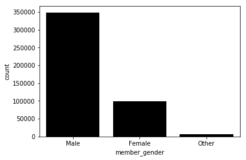

```python
#Plotting gender
sb.countplot(x="member_gender", data=df_copy, color=(0,0,0))
```

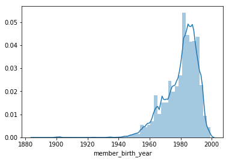

```python
#plotting age
sb.distplot(df_copy['member_birth_year'])
```

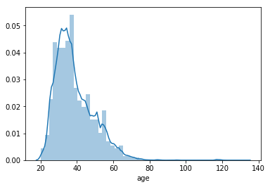

```python
sb.distplot(2019-df_copy['member_birth_year'],axlabel='age')
```

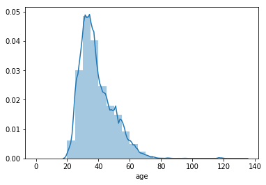

```python
b=np.arange(0,90,5)
sb.distplot(2019-df_copy['member_birth_year'],axlabel='age',bins=b)
```

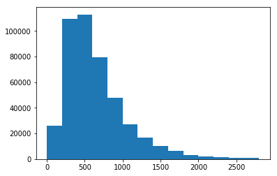

```python
#plotting duration
bin_edges = np.arange(0, 3000, 200);
plt.hist(data=df_copy,x='duration_sec', bins = bin_edges)
```

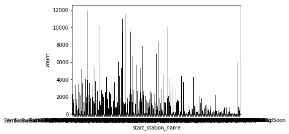

```python
#plotting stations
sb.countplot(x="start_station_name", data=df_copy, color=(0,0,0))
```

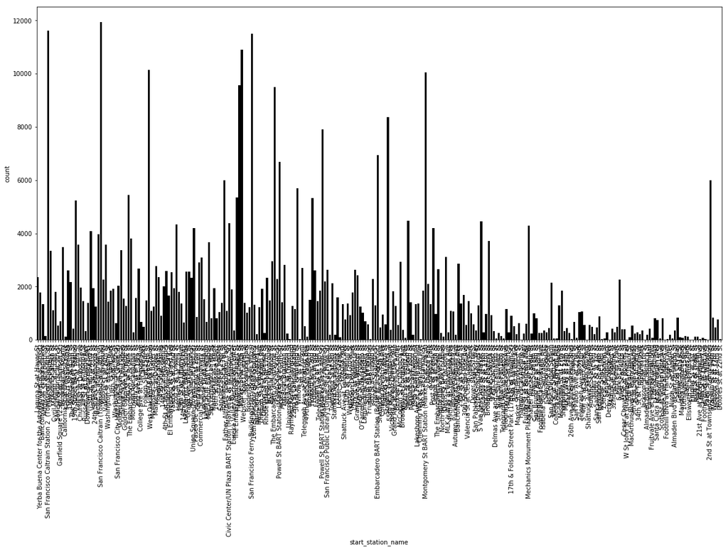

```python
sb.countplot(x="start_station_name", data=df_copy, color=(0,0,0))
plt.xticks(rotation=90)
fig = plt.gcf()
fig.set_size_inches( 20, 10)
```

```python
pop_start_station = []
pop_start_stationr = []
pop_start_station =df_copy.start_station_name.value_counts()
pop_start_stationr =pop_start_station[pop_start_station > 2000]
pop_start_stationr.head()
```

```
San Francisco Caltrain (Townsend St at 4th St)               11929
San Francisco Caltrain Station 2  (Townsend St at 4th St)    11627
San Francisco Ferry Building (Harry Bridges Plaza)           11507
Market St at 10th St                                         10910
Berry St at 4th St                                           10140
Name: start_station_name, dtype: int64
```

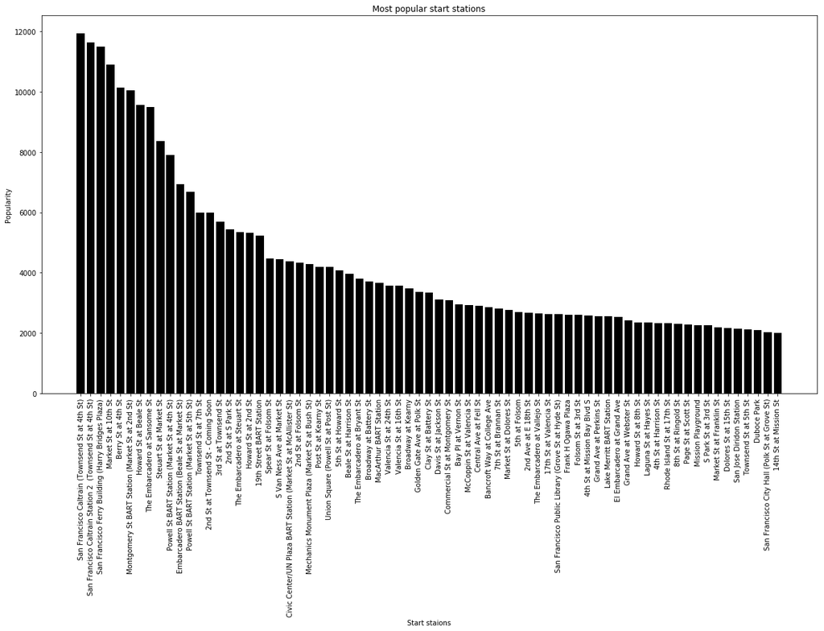

```python
plt.bar(pop_start_stationr.index,pop_start_stationr, color=(0,0,0))
plt.xticks(rotation=90)
fig = plt.gcf()
fig.set_size_inches( 20, 10)
plt.title('Most popular start stations')
plt.xlabel('Start staions')
plt.ylabel('Popularity')
```

```python
pop_end_station = []
pop_end_stationr = []
pop_end_station =df_copy.end_station_name.value_counts()
pop_end_stationr =pop_end_station[pop_end_station > 2000]
pop_end_stationr.head()
```

```
San Francisco Caltrain (Townsend St at 4th St)               16698
San Francisco Ferry Building (Harry Bridges Plaza)           13579
San Francisco Caltrain Station 2  (Townsend St at 4th St)    13108
Montgomery St BART Station (Market St at 2nd St)             12324
The Embarcadero at Sansome St                                10548
Name: end_station_name, dtype: int64
```

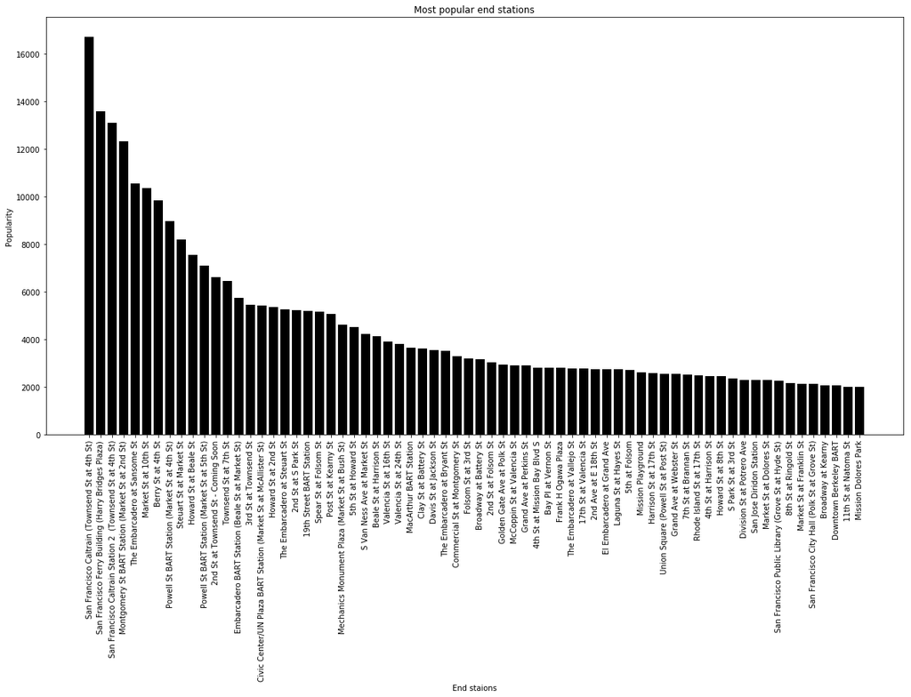

```python
plt.bar(pop_end_stationr.index,pop_end_stationr, color=(0,0,0))
plt.xticks(rotation=90)
fig = plt.gcf()
fig.set_size_inches( 20, 10)
plt.title('Most popular end stations')
plt.xlabel('End staions')
plt.ylabel('Popularity')
```

### Discuss the distribution(s) of your variable(s) of interest. Were there any unusual points? Did you need to perform any transformations?

During the univirate exploration there where some points that where unusual, such as when the age was plotted it wasn't very clear. The graph showed what year someone was born in but it was hard to determin thier age. So 2019 - birth year gave a better idea of someones age at first glance. I wanted to see what stations where the most popular but when this was plotted there were too many staions and it was messy and crowded. The station names were also too large to be seen clearly so they were rotated.

### Of the features you investigated, were there any unusual distributions? Did you perform any operations on the data to tidy, adjust, or change the form of the data? If so, why did you do this?

Some of the values in the gender column were missing and therefore needed removing. There were too many values for the different stations all acorss the city so it was better to just look at the most popular few. This was done by only allowing the stations which get the most use to be plotted.

## Bivariate Exploration

Comparing journey data with destination and further investigate users

```python
station_group =df_copy.groupby(['start_station_name']).sum()
station_group['duration_sec']
```

```
start_station_name
10th Ave at E 15th St                                      158828
10th St at Fallon St                                      1273262
11th St at Bryant St                                      1195997
11th St at Natoma St                                      1472758
12th St at 4th Ave                                         708607
12th St at 6th Ave                                         222770
13th St at Franklin St                                      34970
14th St at Filbert St                                       73390
14th St at Mandela Pkwy                                    767533
14th St at Mission St                                     1591420
16th St Mission BART                                       500198
16th St Mission BART Station 2                             799746
16th St at Prosper St                                      969813
17th & Folsom Street Park (17th St at Folsom St)           733547
17th St at Dolores St                                      928393
17th St at Valencia St                                    1976409
18th St at Noe St                                         1813205
19th St at Florida St                                     1050378
19th St at Mission St                                     1227837
19th Street BART Station                                  3475954
1st St at Folsom St                                       1227857
20th St at Bryant St                                      1627741
21st Ave at International Blvd                              61014
22nd St Caltrain Station                                  1413706
24th St at Chattanooga St                                 1011420
24th St at Market St                                       575354
26th Ave at International Blvd                              78282
29th St at Church St                                      1362741
29th St at Tiffany Ave                                    1498994
2nd Ave at E 18th St                                      2119727
                                                           ...
Telegraph Ave at Carleton St                                34182
The Alameda at Bush St                                     360439
The Embarcadero at Bryant St                              2846847
The Embarcadero at Sansome St                            10182394
The Embarcadero at Steuart St                             4165717
The Embarcadero at Vallejo St                             2350302
Townsend St at 5th St                                     1460143
Townsend St at 7th St                                     4099893
```

[output cut: 8 more lines]

```
Victoria Manalo Draves Park                               1215933
Vine St at Shattuck Ave                                     51393
W St John St at Guadalupe River Trail                        3882
Washington St at 8th St                                    600792
Washington St at Kearny St                                1742118
Webster St at 17th St                                      521064
Webster St at 19th St                                       29379
Webster St at Grove St                                     876822
Webster St at O'Farrell St                                1330541
West Oakland BART Station                                 1152209
West St at 40th St                                         287199
William St at 10th St                                      152044
Willow St at Vine St                                        18306
Yerba Buena Center for the Arts (Howard St at 3rd St)     1507286
Name: duration_sec, Length: 272, dtype: int64
```

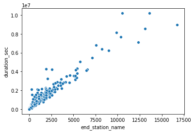

```python
#comapring duration with ending station
sb.scatterplot(pop_end_station,station_group['duration_sec'])
```

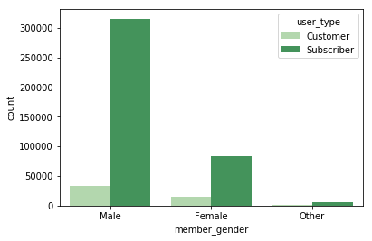

```python
#plotting gender and users type together
sb.countplot(data = df_copy, x = 'member_gender', hue = 'user_type', palette = 'Greens')
```

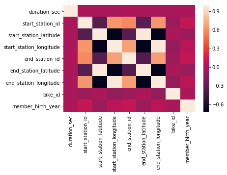

```python
#Seeing correlations for all columns
sb.heatmap(df_copy.corr(method='pearson'))
```

### Talk about some of the relationships you observed in this part of the investigation. How did the feature(s) of interest vary with other features in the dataset?

The first comparison made was to see if the most used stations are also linked to the longest duration bike rides. As this was positive corrolation when plotted it can be seen as being true. The second comparision was made to see if the genders had a difference in proprtion when it came to subscribers vs customers. The finding were that there are more males taht use the service then women in both catagories but far more subcribers use the service compared to customers for all genders.

### Did you observe any interesting relationships between the other features (not the main feature(s) of interest)?

Out of curiosity I had a look at a heat map for all the values in the dataset. It was interesting to see what interactions were made by all the different elements, some had a positive correlation, some had a negative one and others had no correlation at all. It was useful to see what elements would work with each other.

## Multivariate Exploration

Comparing users with other varibles in the dataset

```python
#comapring duration, age and gender
F=df_copy.query('member_gender =="Female"')
M=df_copy.query('member_gender =="Male"')
F=F.reset_index()
M=M.reset_index()
```

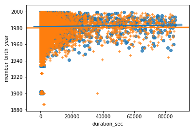

```python
sb.regplot(x=F['duration_sec'],y=F['member_birth_year'], marker='o')
sb.regplot(x=M['duration_sec'],y=M['member_birth_year'],marker='+')
```

```python
c=df_copy.query('user_type =="Customer"')
s=df_copy.query('user_type =="Subscriber"')
c=F.reset_index()
s=M.reset_index()
```

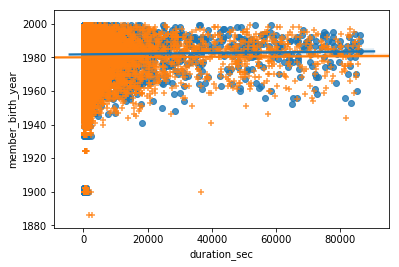

```python
sb.regplot(x=c['duration_sec'],y=c['member_birth_year'], marker='o')
sb.regplot(x=s['duration_sec'],y=s['member_birth_year'],marker='+')
```

[figure not shown]

```python
#add all data points for stations to scatter plot
fig=sb.scatterplot(data=df_copy,x='duration_sec', y='member_birth_year',hue='start_station_name')
fig = plt.gcf()
fig.set_size_inches(20, 10)
```

### Were there any interesting or surprising interactions between features?

When looking at all the stations separatly it was interesting to see that there was similarites between the first comparison and this one but more detail to see the out lyers. For instance seeing multiple members in thier 60s, using the bikes for long duration rides.